# CSE 5243 - Introduction to Data Mining

## Section: 4.2 - Configure and Run the Algorithm

- Do this for (at least) two variations of the configuration settings (if any). Explain all configuration parameter values you chose, and why you chose them.
- For Each Run:
1. Compute the within-cluster WSS, the between-cluster BSS, and the Total SSE (WSS+BSS), and compute the running time.
2. Create a scatterplot, overlaying the true cluster with the cluster produced by your algorithm. (Or alternatively, create two side by side scatterplots).
3. Create a cross tabulation matrix (i.e., confusion matrix) comparing the true and assigned clusters, and the basic measures (precision, recall, F1, accuracy, etc. - see classification_report). Note that you may need to "match up" the true and assigned cluster labels. See the linear-sum-assignment and Hungarian algorithm references, for example.

```python
# Load the data
data = pd.read_csv('large2_Xydf.csv')

X = data[['X0', 'X1']].values
true_labels = data['y'].values

WSS, BSS, total_SSE = calculate_true_clusters(X, true_labels)
print(f"True WSS: {round(WSS, 4)}\nTrue BSS: {round(BSS, 4)}\nTotal SSE: {round(total_SSE, 4)}")
```

```
True WSS: 1917.7276
True BSS: 1219.5688
Total SSE: 3137.2964
```

```python
# Function to perform DBSCAN and calculate WSS, BSS
def dbscan_clustering(X, eps, min_samples):
    start_time = time.time()
    dbscan = DBSCAN(eps=eps, min_samples=min_samples)
    dbscan.fit(X)

    # Assign the predicted labels
    predicted_labels = dbscan.labels_

    # If there are any noise points (-1), exclude them for evaluation
#     if np.any(predicted_labels == -1):
#         print("DBSCAN identified some noise points as -1. These will be excluded.")

    # Calculate WSS and BSS (need to define a function to calculate these)
    WSS, BSS, total_SSE = calculate_true_clusters(X, predicted_labels)

    end_time = time.time()
    execution_time = end_time - start_time

    return WSS, BSS, total_SSE, execution_time, predicted_labels
```

```python
# Run DBSCAN for three different parameter sets
results_dbscan = {}
for eps, min_samples in [(0.1, 2), (0.3, 2), (0.1, 10), (0.3, 10), (0.1, 20), (0.2, 2)]:
    WSS, BSS, total_SSE, execution_time, predicted_labels = dbscan_clustering(X, eps, min_samples)
    results_dbscan[(eps, min_samples)] = {'WSS': round(WSS, 4), 'BSS': round(BSS, 4), 'Total SSE': round(total_SSE, 4), 'Execution Time': round(execution_time, 4)}

for key, value in results_dbscan.items():
    print("For DBSCAN params=", key, ":", value)
```

```
For DBSCAN params= (0.1, 2) : {'WSS': 3113.4176, 'BSS': 23.8789, 'Total SSE': 3137.2964, 'Execution Time': 0.056}
For DBSCAN params= (0.3, 2) : {'WSS': 3137.2964, 'BSS': 0.0, 'Total SSE': 3137.2964, 'Execution Time': 0.103}
For DBSCAN params= (0.1, 10) : {'WSS': 3134.1753, 'BSS': 3.1211, 'Total SSE': 3137.2964, 'Execution Time': 0.051}
For DBSCAN params= (0.3, 10) : {'WSS': 3137.2964, 'BSS': 0.0, 'Total SSE': 3137.2964, 'Execution Time': 0.113}
For DBSCAN params= (0.1, 20) : {'WSS': 2013.1635, 'BSS': 1124.133, 'Total SSE': 3137.2964, 'Execution Time': 0.0491}
For DBSCAN params= (0.2, 2) : {'WSS': 3135.3423, 'BSS': 1.9541, 'Total SSE': 3137.2964, 'Execution Time': 0.076}
```

```python
# Get predicted labels for DBSCAN
eps, min_samples = 0.1, 20  # Default configuration from earlier
db = DBSCAN(eps=eps, min_samples=min_samples).fit(X)

dbscan = DBSCAN(eps=eps, min_samples=min_samples)
dbscan.fit(X)
predicted_labels_dbscan = dbscan.labels_

# Match predicted labels to true labels
matched_labels_dbscan = match_labels(true_labels, predicted_labels_dbscan, len(np.unique(true_labels)))


# Number of clusters in labels, ignoring noise if present.
n_clusters_ = len(set(predicted_labels_dbscan)) - (1 if -1 in predicted_labels_dbscan else 0)
n_noise_ = list(predicted_labels_dbscan).count(-1)

print('Estimated number of clusters: %d' % n_clusters_)
print('Estimated number of noise points: %d' % n_noise_)
```

```
Estimated number of clusters: 2
Estimated number of noise points: 258
```

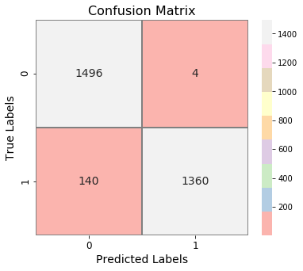

```python
# Confusion matrix
cm = confusion_matrix(true_labels, matched_labels_dbscan)

# Create the heatmap
plt.figure(figsize=(6, 5))
sns.heatmap(
    cm,
    annot=True,
    fmt='d',
    cmap='Pastel1',
    linewidths=0.3,
    linecolor='gray',
    annot_kws={"size": 14}
)
plt.title('Confusion Matrix', fontsize=16)
plt.xlabel('Predicted Labels', fontsize=14)
plt.ylabel('True Labels', fontsize=14)
plt.xticks(fontsize=12)
plt.yticks(fontsize=12)
plt.show()
```

```python
# Classification report
report = classification_report(true_labels, matched_labels_dbscan, output_dict=True)

report_df = pd.DataFrame(report).transpose()

# Display the report
print("Classification Report:")
report_df
```

```
Classification Report:
```

|  | precision | recall | f1-score | support |
| --- | --- | --- | --- | --- |
| 0 | 0.914425 | 0.997333 | 0.954082 | 1500.000 |
| 1 | 0.997067 | 0.906667 | 0.949721 | 1500.000 |
| accuracy | 0.952000 | 0.952000 | 0.952000 | 0.952 |
| macro avg | 0.955746 | 0.952000 | 0.951901 | 3000.000 |
| weighted avg | 0.955746 | 0.952000 | 0.951901 | 3000.000 |

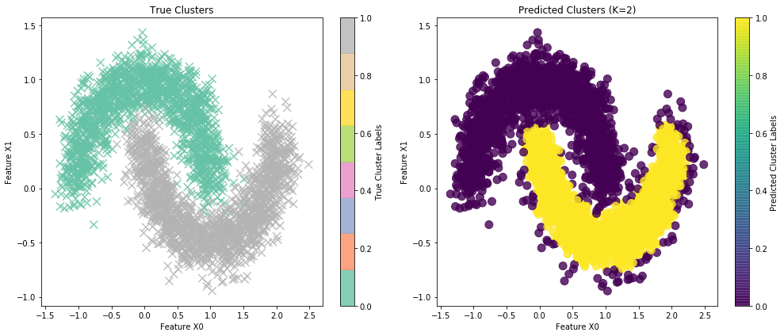

```python
# Enhanced side-by-side scatter plot with better visuals
plt.figure(figsize=(14, 6))

# Plot for true clusters
plt.subplot(1, 2, 1)
scatter_true = plt.scatter(X[:, 0], X[:, 1], c=true_labels, cmap='Set2', marker='x', alpha=0.8, s=100)
plt.title('True Clusters')
plt.xlabel('Feature X0')
plt.ylabel('Feature X1')
plt.colorbar(scatter_true, label='True Cluster Labels')

# Plot for predicted clusters
plt.subplot(1, 2, 2)
scatter_pred = plt.scatter(X[:, 0], X[:, 1], c=matched_labels_dbscan, cmap='viridis', marker='o', alpha=0.8, s=100)
plt.title('Predicted Clusters (K=2)')
plt.xlabel('Feature X0')
plt.ylabel('Feature X1')
plt.colorbar(scatter_pred, label='Predicted Cluster Labels')

plt.tight_layout()
plt.show()
```